# R Notebook

## Aim

- [Gender identity (detailed)](https://www.ons.gov.uk/datasets/TS070/editions/2021/versions/3) - this dataset classifies usual residents aged 16 years and over in England and Wales by gender identity.
- [Local Authority District Boundaries](https://geoportal.statistics.gov.uk/datasets/bb53f91cce9e4fd6b661dc0a6c734a3f_0/about) - this file contains the digital vector boundaries for Local Authority Districts in the UK as of May 2022.

## Install packages

If you’re running this code on your own PC (and not through the Binder link) then you’re going to want to uncomment the lines below so you can install the requisite packages. Another thing to remember is to set your working directory to the correct folder. Otherwise reading in data will be difficult.

```r
# install.packages("leaflet")
# install.packages("sf")
# install.packages("dplyr")
# install.packages("readr")
```

## Import libraries

```r
# used to read-in datasets
library(readr)
# used to manipulate datasets
library(dplyr)
# used to read-in spatial data, shapefiles
library(sf)
# used to create interactive maps
library(leaflet)
```

## Read-in dataset

```r
# First, let's read in our gender identity dataset

df <- read_csv('Data/GI_det.csv')
# Use head function to check out the first few rows - but can also access df via environment pane

head(df, 10)
```

| Lower tier local authorities Code | Lower tier local authorities | Gender identity (8 categories) Code | Gender identity (8 categories) | Observation |
| --- | --- | --- | --- | --- |
| E06000001 | Hartlepool | -8 | Does not apply | 0 |
| E06000001 | Hartlepool | 1 | Gender identity the same as sex registered at birth | 70588 |
| E06000001 | Hartlepool | 2 | Gender identity different from sex registered at birth but no specific identity given | 167 |
| E06000001 | Hartlepool | 3 | Trans woman | 49 |
| E06000001 | Hartlepool | 4 | Trans man | 51 |
| E06000001 | Hartlepool | 5 | Non-binary | 33 |
| E06000001 | Hartlepool | 6 | All other gender identities | 21 |
| E06000001 | Hartlepool | 7 | Not answered | 3777 |
| E06000002 | Middlesbrough | -8 | Does not apply | 0 |
| E06000002 | Middlesbrough | 1 | Gender identity the same as sex registered at birth | 106009 |

## Data Cleaning

Before we can calculate the %’s of trans men in each local authority, it’s good to do some housekeeping and get our dataframe in order. There’s a few things that need sorting including:

1. renaming columns so they are easier to reference
2. removing ‘Does not apply’ from gender identity category
3. renaming some values in gender identity category so they aren’t as wordy

### Pipe operator - %>%

The pipe operator is used to pass the result of one function directly into the next one. E.g. let’s say we had some code:

```
sorted_data \<- my_data %\>% filter(condition) %\>% arrange(sorting_variable)
```

What we’re doing is using the pipe operator to pass my_data to the filter() function, and the result of this is then passed to the arrange() function. Basically, pipes allow us to chain together a sequence of functions in a way that’s easy to read and understand.

In the code below we use the pipe operator to pass our dataframe to the rename function. This basically supplies the rename function with its first argument, which is the dataframe to filter on.

### 1

```r
# Rename columns using the rename function from dplyr
# Specify what you want to rename the column to, and supply the original column string

df <- df %>%
  rename(LA_code = `Lower tier local authorities Code`,
         LA_name = `Lower tier local authorities`,
         GI_code = `Gender identity (8 categories) Code`,
         GI_cat = `Gender identity (8 categories)`)


# Let's use the colnames function to see if it worked

colnames(df)
```

```
[1] "LA_code"     "LA_name"     "GI_code"     "GI_cat"      "Observation"
```

### 2

### Logical operators - ==, !=, <, >, <=, >=, &, |, !

Logical operators are used to perform comparisons between values or expressions, which result in a logical (Boolean) value of ‘TRUE’ or ‘FALSE’. In the code below we use the ‘!=’ ‘Does not equal’ operator which tests if the GI_cat column in each row of the df does not equal the string ‘Does not apply’. For each row where GI_cat is not equal to ‘Does not apply’, the expression valuates to TRUE. We filter so we only keep rows where this expression evaluates to TRUE.

```r
# To get rid of the 'Does not apply' category in the gender identity category column, we use dplyr's filter function
# And we use a conditional '!=' to keep everything except 'Does not apply' category

df <- df %>% filter(GI_cat != 'Does not apply')
```

### Dollar sign operator - $

This operator is used to access elements, such as columns of a dataframe, by name. Below, we use it to access the gender identity category column, where we want to view the unique values.

```r
# Unique function can be applied to a column in a df to see which values are in that column
# Let's see if 'Does not apply' has been successfully dropped

unique(df$GI_cat)
```

```
[1] "Gender identity the same as sex registered at birth"                                   "Gender identity different from sex registered at birth but no specific identity given"
[3] "Trans woman"                                                                           "Trans man"
[5] "Non-binary"                                                                            "All other gender identities"
[7] "Not answered"
```

### 3

```r
# We can use the recode function on a column to replace values in a column

df$GI_cat <- df$GI_cat %>%
  recode(`Gender identity the same as sex registered at birth` = "Gender identity the same as sex",
         `Gender identity different from sex registered at birth but no specific identity given` = "Gender identity different from sex")


# Let's see if it worked...

unique(df$GI_cat)
```

```
[1] "Gender identity the same as sex"    "Gender identity different from sex" "Trans woman"                        "Trans man"                          "Non-binary"
[6] "All other gender identities"        "Not answered"
```

## Data Pre-processing

Now onto the more interesting stuff. The data pre-processing stage involves preparing and transforming data into a suitable format for further analysis. It can involve selecting features, transforming variables, and creating new variables. For our purposes, we need to create a new column ‘Percentages’ which contains the % of Trans men in each local authority. So, we’ll need to first calculate the % of each gender identity category for each local authority. Then, we’ll want to filter our dataset so that we only keep the responses related to Trans men.

```r
# Use group_by to group the dataframe by the LA_name column
# Use mutate to perform calculation within each LA_name group, convert result to a % by multiplying by 100
# round() is used to round %'s to 2 decimal places

df <- df %>%
  group_by(LA_name) %>%
  mutate(Percentage = round(Observation / sum(Observation) * 100, 2))

# Let's check out the results

head(df)
```

| LA_code | LA_name | GI_code | GI_cat | Observation | Percentage |
| --- | --- | --- | --- | --- | --- |
| E06000001 | Hartlepool | 1 | Gender identity the same as sex | 70588 | 94.51 |
| E06000001 | Hartlepool | 2 | Gender identity different from sex | 167 | 0.22 |
| E06000001 | Hartlepool | 3 | Trans woman | 49 | 0.07 |
| E06000001 | Hartlepool | 4 | Trans man | 51 | 0.07 |
| E06000001 | Hartlepool | 5 | Non-binary | 33 | 0.04 |
| E06000001 | Hartlepool | 6 | All other gender identities | 21 | 0.03 |

```r
# Use filter() to only keep rows where GI_cat equals 'Trans man'
df <- df %>%
  filter(GI_cat == 'Trans man') %>%
  # Use select() with '-' to remove 'Observation' column
  select(-Observation) %>%
  # Use distinct() to remove duplicate rows
  distinct() %>%
  # Use ungroup() to remove grouping - resetting the dataframes state after performing group operations is good practice
  ungroup()

# Let's take a look at the results
head(df)
```

| LA_code | LA_name | GI_code | GI_cat | Percentage |
| --- | --- | --- | --- | --- |
| E06000001 | Hartlepool | 4 | Trans man | 0.07 |
| E06000002 | Middlesbrough | 4 | Trans man | 0.15 |
| E06000003 | Redcar and Cleveland | 4 | Trans man | 0.09 |
| E06000004 | Stockton-on-Tees | 4 | Trans man | 0.08 |
| E06000005 | Darlington | 4 | Trans man | 0.08 |
| E06000006 | Halton | 4 | Trans man | 0.08 |

## Read-in shapefile

Now that we have our gender identity dataset sorted, we can start on the mapping process. And that starts with reading in our shapefile, which we should have downloaded from the geoportal. If (like me) you don’t work with spatial data much, you might assume that you only need the shapefile, and you might delete the others that come with the folder. However, a shapefile is not just a single .shp file, but a collection of files that work together, and each of these files plays a crucial role in defining the shapefile’s data and behaviour. When you try and read a shapefile into R, the software expects all components to be present, and missing them can lead to errors or incorrect spatial references. E.g. without the .dbf file, you’d lose all attribute data associated with the geographic features, and withou tthe .shx file you might not be able to read the .shp file altogether.

**TLDR: Make sure when you download the shapefile folder you keep all the files!**

Anyway, let’s get started.

```r
# First, read in shapefile to a simple features object
# st_read() reads in spatial data to a 'simple features' object

sf <- st_read('Shapefiles/LADs/LAD_MAY_2022_UK_BFE_V3.shp')
# Let's check it out

head(sf)
```

```
Simple feature collection with 6 features and 7 fields
Geometry type: MULTIPOLYGON
Dimension:     XY
Bounding box:  xmin: 344666.1 ymin: 378867 xmax: 478453.7 ymax: 537152
Projected CRS: OSGB 1936 / British National Grid
    LAD22CD              LAD22NM  BNG_E  BNG_N     LONG     LAT                             GlobalID                       geometry
1 E06000001           Hartlepool 447160 531474 -1.27018 54.6761 2efc9848-300e-4ef3-a36e-58d6856b9817 MULTIPOLYGON (((447213.9 53...
2 E06000002        Middlesbrough 451141 516887 -1.21099 54.5447 6d66b015-1f67-40f6-b239-15911fa03834 MULTIPOLYGON (((448489.9 52...
3 E06000003 Redcar and Cleveland 464361 519597 -1.00608 54.5675 a5a6513f-916e-4769-bed2-cd019d18719a MULTIPOLYGON (((455525.9 52...
4 E06000004     Stockton-on-Tees 444940 518183 -1.30664 54.5569 14e8450b-7e7c-479a-a335-095ac2d9a701 MULTIPOLYGON (((444157 5279...
5 E06000005           Darlington 428029 515648 -1.56835 54.5353 2f212ecf-daf5-4171-b9c6-825c0d33e5af MULTIPOLYGON (((423496.6 52...
6 E06000006               Halton 354246 382146 -2.68853 53.3342 79d75109-ea21-4148-b303-ce7d03795d27 MULTIPOLYGON (((351539.9 38...
```

```r
# Inspect shape
dim(sf)
```

```
[1] 374   8
```

```r
# length() with the unique() function gives us the number of unique values in a column

length(unique(sf$LAD22NM))
```

```
[1] 374
```

## Cleaning shapefile

Hmm.We have 331 local authorities in our dataset that we want to plot, but there are 374 listed here. We’ll need to remove the local authorities that don’t match the ones in our df.

1. rename columns to match ‘df’
2. get rid of redundant Local Authorities

### 1

```r
# Use rename function so sf columns match those in original df

sf <- sf %>%
  rename(LA_code = LAD22CD,
         LA_name = LAD22NM)

# Let's see if it worked
colnames(sf)
```

```
[1] "LA_code"  "LA_name"  "BNG_E"    "BNG_N"    "LONG"     "LAT"      "GlobalID" "geometry"
```

```r
# Replace specific values in the LA_name column using recode()

sf$LA_name <- sf$LA_name %>%
  recode(`Bristol, City of` = "Bristol",
         `Kingston upon Hull, City of` = "Kingston upon Hull",
         `Herefordshire, County of` = "Herefordshire")
```

### 2

### %in% operator

This is used to check if elements of one list are in another list. Much like the logical operators, it returns a boolean value TRUE or FALSE. And we only keep rows in the LA_code for the ‘sf’ dataset, if they are present in the LA_code column in ‘df’.

```r
# Use filter() with %in% and unique() to only keep LA's that match

sf <- sf %>%
  filter(LA_code %in% unique(df$LA_code))

# Let's see how it looks..
# We should have 331 unique LA_codes
length(unique(sf$LA_code))
```

```
[1] 331
```

## Pre-processing shapefile

When it comes to mapping our data, it is important that we know which Coordinate Reference System (CRS) we are working with. Simply put, the CRS is a way to describe how the spatial data in the ‘sf’ object maps to locations on earth. The CRS is just a way of translating 3D reality into 2D maps. And when it comes to using mapping libraries like ‘leaflet’, knowing the CRS is important because leaflet expects coordinates in a specific format (usually latitude and longitude), which is EPSG:4326. If our CRS isn’t in this format then we might need to transform it so that it matches what leaflet expects. Let’s go ahead and see what our CRS is saying.

```r
st_crs(sf)
```

```
Coordinate Reference System:
  User input: OSGB 1936 / British National Grid
  wkt:
PROJCRS["OSGB 1936 / British National Grid",
    BASEGEOGCRS["OSGB 1936",
        DATUM["OSGB 1936",
            ELLIPSOID["Airy 1830",6377563.396,299.3249646,
                LENGTHUNIT["metre",1]]],
        PRIMEM["Greenwich",0,
            ANGLEUNIT["degree",0.0174532925199433]],
        ID["EPSG",4277]],
    CONVERSION["British National Grid",
        METHOD["Transverse Mercator",
            ID["EPSG",9807]],
        PARAMETER["Latitude of natural origin",49,
            ANGLEUNIT["degree",0.0174532925199433],
            ID["EPSG",8801]],
        PARAMETER["Longitude of natural origin",-2,
            ANGLEUNIT["degree",0.0174532925199433],
            ID["EPSG",8802]],
        PARAMETER["Scale factor at natural origin",0.9996012717,
            SCALEUNIT["unity",1],
            ID["EPSG",8805]],
        PARAMETER["False easting",400000,
            LENGTHUNIT["metre",1],
            ID["EPSG",8806]],
        PARAMETER["False northing",-100000,
            LENGTHUNIT["metre",1],
            ID["EPSG",8807]]],
    CS[Cartesian,2],
        AXIS["(E)",east,
            ORDER[1],
            LENGTHUNIT["metre",1]],
        AXIS["(N)",north,
            ORDER[2],
            LENGTHUNIT["metre",1]],
    USAGE[
        SCOPE["Engineering survey, topographic mapping."],
        AREA["United Kingdom (UK) - offshore to boundary of UKCS within 49°45'N to 61°N and 9°W to 2°E; onshore Great Britain (England, Wales and Scotland). Isle of Man onshore."],
        BBOX[49.75,-9,61.01,2.01]],
    ID["EPSG",27700]]
```

```r
# To transform our crs to EPSG: 4326, simply use st_transform() and specify the crs
# Note: you don't have to use the %>% pipe operator all the time
sf <- st_transform(sf, crs = 4326)
```

### Merge datasets

What we want to do now is merge our ‘df’ dataframe with our ‘sf’ spatial object, so that we can directly access the data and map it! When you use the merge function in R, the order in which you place the data matters in terms of the result’s class type and spatial attributes. So, in terms of class type, we have a dataframe and a spatial object. By placing ‘sf’ first, the result will be a spatial object, which is important because this retains the spatial characteristics and geometry columns of the ‘sf’ object. We merge the columns on the LA_code and LA_name columns which are present in both datasets.

### ‘c’ function

Don’t overthink it. It’s just a way to group items together in R, whether for defining a set of values to work with, specifying parameters for a function, or any number of other uses where a list of items is needed.

```r
# Merge the dataframes
merged <- merge(sf, df, by = c('LA_code', 'LA_name'))

# Let's check it out
head(merged, 20)
```

[output not shown]

## Building our interactive map

Finally, we can now build out interactive map using leaflet. You can see from the ‘geometry’ column that we’re working with ‘MULTIPOLYGON’s’ which are a collection of polygons grouped together as a single geometric entity. Basically, multipolygons are good at representing complex shapes. And we have 331 to plot. You can take a look at these separate multipolygons by using the plot function and indexing the row and column (see below).

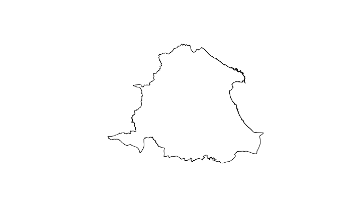

```r
plot(sf[1, 'geometry'])
```

```r
# Define the color palette for filling in our multipolygon shapes
# domain sets the range of data values that the colour scale should cover
color_palette <- colorNumeric(palette = "YlGnBu", domain = merged$Percentage)

# Use leaflet function with 'merged' dataset
uk_map <- leaflet(merged) %>%
  # Centers the map on long and lat for UK
  setView(lng = -3.0, lat = 53, zoom = 6) %>%
  # Adds default map tiles (the visual image of the map)
  addTiles() %>%
  # Adds multipolygons to the map, and colours them based on the 'Percentage' column
  # We use the palette we created above
  addPolygons(
    fillColor = ~color_palette(Percentage),
    weight = 1, # Set the border weight to 1 for thinner borders
    color = "#000000",
    fillOpacity = 0.7,
    highlightOptions = highlightOptions(color = "white", weight = 2, bringToFront = TRUE),
    label = ~paste(LA_name, ":", Percentage, "%"), # This will create tooltips showing the info
    labelOptions = labelOptions(
      style = list("font-weight" = "normal", padding = "3px 8px"),
      textsize = "12px", direction = "auto") # Adjust text size as needed
  ) %>%
  addLegend(pal = color_palette, values = ~Percentage, opacity = 0.7, title = "Percentage", position = "topright")

# Render the map
uk_map
```

[output not shown]